# Chapter 09, Problem Set Key

### 9.1

Derive the conditions for the $\alpha$s that distinguish between a stable node and unstable point at zero (i.e., the difference between figure 9.1C and D) for the basic mutualism equations.

### 9.2

Modify the basic mutualism equations to model the idea of an “obligate” mutualism (defined as a population that will tend toward zero if its mutualist partner does not exist).

If you take the equation
$$\frac{\mathrm{d}N_1}{\mathrm{d}t} = r_1N_1\left(\frac{K_1 - N_1 + \alpha _{12}N_2}{K_1}\right) \\
\frac{\mathrm{d}N_2}{\mathrm{d}t} = r_2N_2\left(\frac{K_2 - N_2 + \alpha _{21}N_2}{K_2}\right)$$
and set $K_i$ or $r_i$ to be $<0$, then the populations will tned to zero if its mutualist partner does not exist or if their effect (i.e., $\alpha _{ij}$) is strong enough.

### 9.5

How would you modify equation set 1 to include the logic of figure 9.5 analytically? Hint: Recall the definition of a type II functional response from chapter 6.

### 9.6

Find the isoclines of the system derived in exercise 9.5, and plot them in the phase plane.

To incorporate the type II functional response from chapter 6, it would look something like this:

$$\frac{\mathrm{d}N_1}{\mathrm{d}t} = r_1N_1\left(\frac{K_1 - N_1 + \frac{\alpha _{12}N_2}{h_{12} + N_2}}{K_1}\right) \\
\frac{\mathrm{d}N_2}{\mathrm{d}t} = r_2N_2\left(\frac{K_2 - N_2 + \frac{\alpha _{21}N_1}{h_{21} + N_1}}{K_2}\right)$$
I did verbally say that the function could be set outside the euqation (i.e., not divided by $K_i$), and you should get saturating curves there, too. But, to solve the first equation after removing $N_1$ since that isocline is equal to 0 we can do some albebra to put $N_2$ on the left-hand side:

$$0 = r_1\left(\frac{K_1 - N_1 + \frac{\alpha _{12}N_2}{h_{12} + N_2}}{K_1}\right) \\
0 = \frac{r_1}{K_1}K_1 - \frac{r_1}{K_1}N_1 + \frac{r_1}{K_1}\frac{\alpha _{12}N_2}{h_{12} + N_2} \\
-\frac{r_1}{K_1}\frac{\alpha _{12}N_2}{h_{12} + N_2} = \frac{r_1}{K_1}K_1 - \frac{r_1}{K_1}N_1 \\
\frac{r_1}{K_1}\frac{\alpha _{12}N_2}{h_{12} + N_2} = \frac{r_1}{K_1}N_1 - \frac{r_1}{K_1}K_1 \\
r_1\frac{\alpha _{12}N_2}{h_{12} + N_2} = r_1N_1 - r_1K_1 \\
\alpha _{12}N_2 = (N_1 - K_1)(h_{12} + N_2) \\
\alpha _{12}N_2 = (N_1 - K_1)h_{12} + (N_1 - K_1)N_2 \\
\alpha _{12}N_2 - (N_1 - K_1)N_2= (N_1 - K_1)h_{12} \\
N_2(\alpha _{12} - N_1 + K_1) = (N_1 - K_1)h_{12} \\
N_2 = \frac{(N_1 - K_1)h_{12}}{\alpha _{12} - N_1 + K_1} \\$$

To solve the second equation after removing $N_2$ since that isocline is equal to 0 we can do some albebra to put $N_2$ on the left-hand side:

$$0 = r_2\left(\frac{K_2 - N_2 + \frac{\alpha _{21}N_1}{h_{21} + N_1}}{K_2}\right) \\
0 = \frac{r_2}{K_2}K_2 - \frac{r_2}{K_2}N_2 + \frac{r_2}{K_2}\frac{\alpha _{21}N_1}{h_{21} + N_1} \\
\frac{r_2}{K_2}N_2 = \frac{r_2}{K_2}K_2 + \frac{r_2}{K_2}\frac{\alpha _{21}N_1}{h_{21} + N_1} \\
r_2N_2 = r_2K_2 + r_2\frac{\alpha _{21}N_1}{h_{21} + N_1} \\
N_2 = K_2 + \frac{\alpha _{21}N_1}{h_{21} + N_1} \\$$

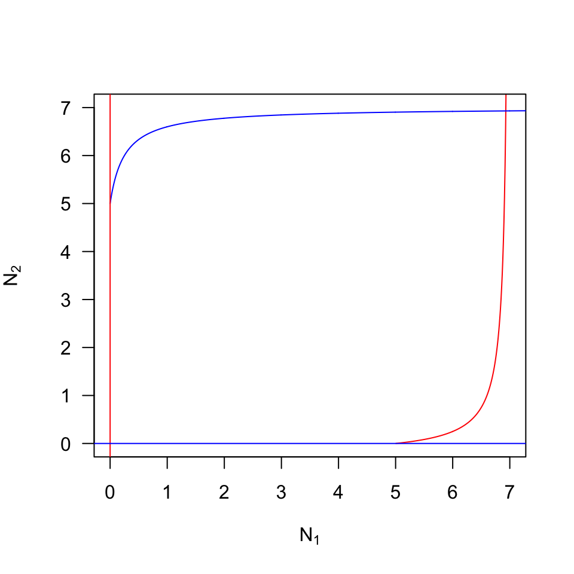

```r
n_x <- 1000
alpha12 <- alpha21 <- 2
K1 <- K2 <- 5
h12 <- h21 <- 0.25
N1_seq <- seq(from = 0, to = 10, length.out = n_x)
N2_eqn1 <- h12*(N1_seq - K1)/(alpha12 - N1_seq + K1)
N2_eqn2 <- K2 + alpha21*N1_seq/(h21 + N1_seq)

N1_seq_pos <- which(N2_eqn1 > 0)
  # See what I did above? I indexed all the negative values and when I
  # go to plot below, I subset the x and y vectors for just
  # these positive values

plot_lims <- c(0, 7)
plot(x = N1_seq[N1_seq_pos], y = N2_eqn1[N1_seq_pos], col = "red", type = "l", xlim = plot_lims, ylim = plot_lims, las = 1, xlab = bquote("N"[1]), ylab = bquote("N"[2]))
  lines(x = N1_seq, y = N2_eqn2, col = "blue")
  segments(x0 = 0, x1 = 0, y0 = -1, y1 = 10, col = "red")
  segments(x0 = -1, x1 = 10, y0 = 0, y1 = 0, col = "blue")
```

### 9.7

Repeat the exercise in figure 9.5, butgive the $N_2$ isocline the saturating feature while $N_1$ remains linear.

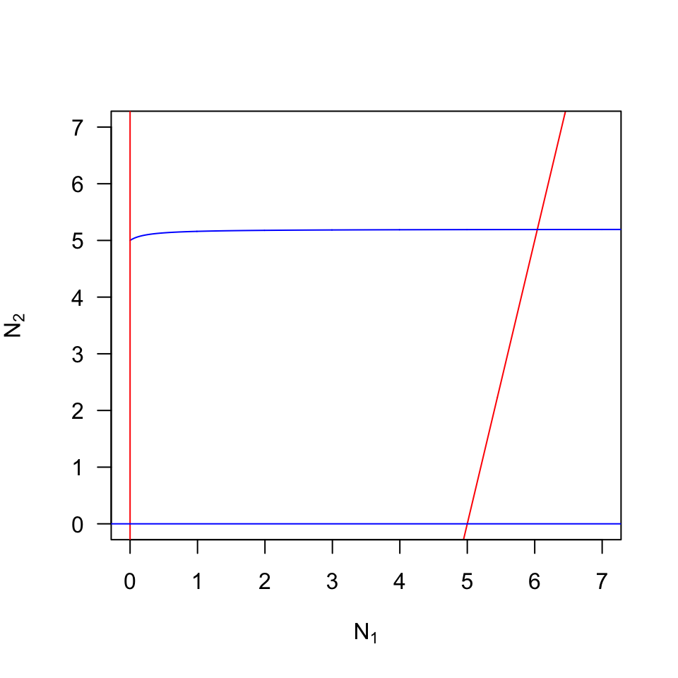

```r
n_x <- 1000
alpha12 <- alpha21 <- 0.2
  #shrunk alphas so isoclines cross given my axis limits
K1 <- K2 <- 5
h12 <- h21 <- 0.25
N1_seq <- seq(from = 0, to = 10, length.out = n_x)
N2_eqn1 <- -K1/alpha12 + 1/alpha12*N1_seq
N2_eqn2 <- K2 + alpha21*N1_seq/(h21 + N1_seq)

plot_lims <- c(0, 7)
plot(x = N1_seq, y = N2_eqn1, col = "red", type = "l", xlim = plot_lims, ylim = plot_lims, las = 1, xlab = bquote("N"[1]), ylab = bquote("N"[2]))
  lines(x = N1_seq, y = N2_eqn2, col = "blue")
  segments(x0 = 0, x1 = 0, y0 = -1, y1 = 10, col = "red")
  segments(x0 = -1, x1 = 10, y0 = 0, y1 = 0, col = "blue")
```

### 9.X

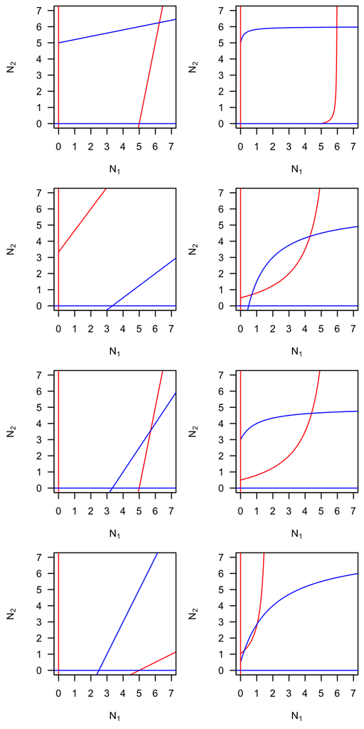

```r
n_x <- 1000
N1_seq <- seq(from = 0, to = 10, length.out = n_x)

# Panel A
alpha12 <- alpha21 <- 0.2
K1 <- K2 <- 5
N2_eqn1_A <- -K1/alpha12 + 1/alpha12*N1_seq
N2_eqn2_A <- K2 + alpha21*N1_seq

# Panel B
alpha12 <- alpha21 <- 1
h12 <- h21 <- 0.2
N2_eqn1_B <- h12*(N1_seq - K1)/(alpha12 - N1_seq + K1)
N2_eqn2_B <- K2 + alpha21*N1_seq/(h21 + N1_seq)
N1_seq_pos_B <- which(N2_eqn1_B > 0)

# Panel C
alpha12 <- alpha21 <- 0.75
K1 <- K2 <- 2.5
N2_eqn1_C <- K1/alpha12 + 1/alpha12*N1_seq
N2_eqn2_C <- -K2 + alpha21*N1_seq

# Panel D
K1 <- -3
K2 <- -3
alpha12 <- 9
alpha21 <- 9
h12 <- 1
h21 <- 1
N2_eqn1_D <- h12*(N1_seq - K1)/(alpha12 - N1_seq + K1)
N2_eqn2_D <- K2 + alpha21*N1_seq/(h21 + N1_seq)
N1_seq_pos_D <- which(N2_eqn1_D > 0)

# Panel E
K1 <- -5
K2 <- -5
alpha12 <- 0.2
alpha21 <- 1.5
N2_eqn1_E <- K1/alpha12 + 1/alpha12*N1_seq
N2_eqn2_E <- K2 + alpha21*N1_seq

# Panel F
K1 <- -3
K2 <- 3
alpha12 <- 9
alpha21 <- 2
h12 <- 1
h21 <- 1
N2_eqn1_F <- h12*(N1_seq - K1)/(alpha12 - N1_seq + K1)
N2_eqn2_F <- K2 + alpha21*N1_seq/(h21 + N1_seq)
N1_seq_pos_F <- which(N2_eqn1_F > 0)

# Panel G
alpha12 <- alpha21 <- 2
K1 <- 5
K2 <- -5
N2_eqn1_G <- -K1/alpha12 + 1/alpha12*N1_seq
N2_eqn2_G <- K2 + alpha12*N1_seq

# Panel H
K1 <- -7.25
K2 <- 0.5
alpha12 <- 9
alpha21 <- 7
h12 <- 0.25
h21 <- 2
N2_eqn1_H <- h12*(N1_seq - K1)/(alpha12 - N1_seq + K1)
N2_eqn2_H <- K2 + alpha21*N1_seq/(h21 + N1_seq)
N1_seq_pos_H <- which(N2_eqn1_H > 0)



plot_lims <- c(0, 7)

phase_plot <- function(x_seq, N1, N2, lims) {
  plot(x = x_seq, y = N1, col = "red", type = "l", xlim = lims, ylim = lims, las = 1, xlab = bquote("N"[1]), ylab = bquote("N"[2]))
  lines(x = N1_seq, y = N2, col = "blue")
  segments(x0 = 0, x1 = 0, y0 = -1, y1 = 10, col = "red")
  segments(x0 = -1, x1 = 10, y0 = 0, y1 = 0, col = "blue")
}


par(mfrow = c(4, 2), mar = c(4.5, 4.5, 0.5, 0.5))
# Panel A
  phase_plot(x_seq = N1_seq, N1 = N2_eqn1_A, N2 = N2_eqn2_A, lims = plot_lims)
# Panel B
  phase_plot(x_seq = N1_seq[N1_seq_pos_B], N1 = N2_eqn1_B[N1_seq_pos_B], N2 = N2_eqn2_B, lims = plot_lims)
# Panel C
  phase_plot(x_seq = N1_seq, N1 = N2_eqn1_C, N2 = N2_eqn2_C, lims = plot_lims)
# Panel D
  phase_plot(x_seq = N1_seq[N1_seq_pos_D], N1 = N2_eqn1_D[N1_seq_pos_D], N2 = N2_eqn2_D, lims = plot_lims)
# Panel E
  phase_plot(x_seq = N1_seq, N1 = N2_eqn1_E, N2 = N2_eqn2_E, lims = plot_lims)
# Panel F
  phase_plot(x_seq = N1_seq[N1_seq_pos_F], N1 = N2_eqn1_F[N1_seq_pos_F], N2 = N2_eqn2_F, lims = plot_lims)
# Panel G
  phase_plot(x_seq = N1_seq, N1 = N2_eqn1_G, N2 = N2_eqn2_G, lims = plot_lims)
# Panel H
  phase_plot(x_seq = N1_seq[N1_seq_pos_H], N1 = N2_eqn1_H[N1_seq_pos_H], N2 = N2_eqn2_H, lims = plot_lims)
```